# Modelling the impact of increasing sources using Bayesian, non-linear (power function) regressions

# References

- Bond, R. (2005). Group Size and Conformity. *Group Processes & Intergroup Relations*, *8*(4), 331–354. https://doi.org/10.1177/1368430205056464
- Latané, B. (1981). The psychology of social impact. *American Psychologist*, *36*(4), 343–356. https://doi.org/10.1037/0003-066X.36.4.343
- Paul-Christian Buerkner (2017). brms: An R Package for Bayesian Multilevel Models Using Stan. *Journal of Statistical Software*, 80(1), 1-28. `doi:10.18637/jss.v080.i01`
- Paul-Christian Buerkner (2018). Advanced Bayesian Multilevel Modeling with the R Package brms. *The R Journal*. 10(1), 395–411. `doi:10.32614/RJ-2018-017`
- The Stan Development Team (n.d). *Stan Modeling Language User’s Guide and Reference Manual*. https://mc-stan.org/users/documentation/.
- Stan Development Team (2020). RStan: the R interface to Stan. R package version 2.21.2. https://mc-stan.org/

# Comparing prior belief vs. baseline

A relevant question for relevant for our modelling approach is how to deal with participants’ reported prior beliefs compared to the baseline condition, where there is 1 person agreeing with the claim, and 1 person disagreeing. In theory, it would be nice to control for people’s prior beliefs in some way. In all of my previous consensus studies we have done this, in order to account for the fact that people who already have strong prior beliefs are less likely to shift them. There are a few problems with this in the current study, though.

## Does confidence change from prior to baseline?

If we can treat prior and baseline as essentially the same, this will vastly simplify our modelling, as we can treat the baseline condition as people’s priors. First, let’s check the correlation

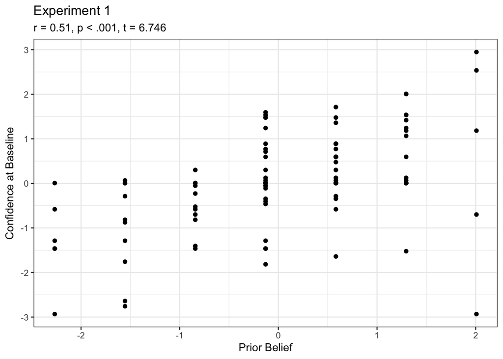

```r
source(here("analyses/prior-baseline-comparison.R"))

all_corr_plots <- vector("list", length = length(experiments))

for (i in 1:length(experiments)){
  all_corr_plots[[i]] <- checkPriorBaselineCorr(i)
}


combined_corr_plot <- ggarrange(plotlist = all_corr_plots)
combined_corr_plot
```

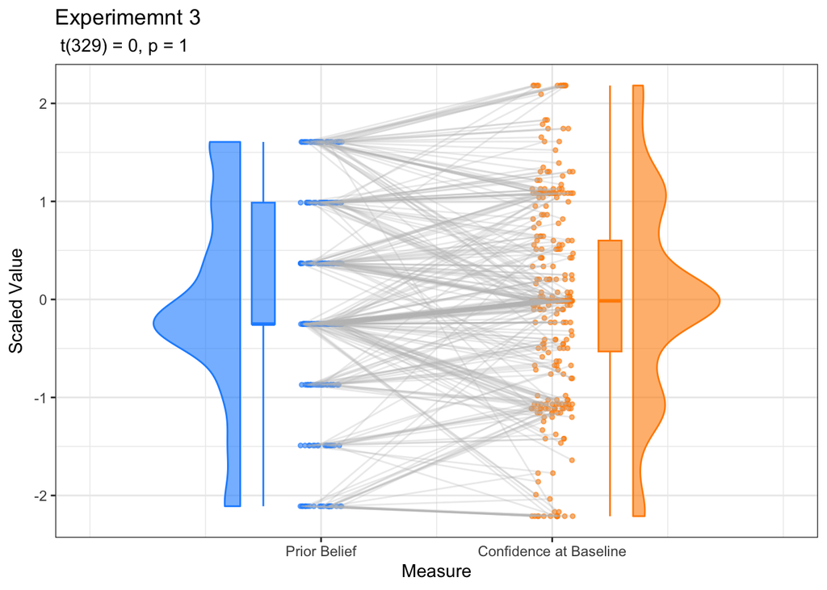

```r
all_group_plots <- vector("list", length = length(experiments))

for (i in 1:length(experiments)){
  exp <- experiments[i]
  all_group_plots[[i]] <- checkPriorBaselineGroups(exp)
}


combined_group_plot <- ggarrange(plotlist = all_group_plots)
combined_group_plot
```

Something else that’s interesting is that the baseline condition seems to bring the distribution more towards the middle, somewhat nullifying the effect of priors (i.e., the baseline distribution is more symmetrical around 0).

Taken together, I would argue that it’s safe to ignore prior beliefs in the modelling and instead focus only on how beliefs change from baseline.